# MECH476: Engineering Data Analysis in R

Chapter 7 Homework: Multivariate Exploratory Data Analysis

Daniel Pelphrey

26 October, 2023

# Chapter 7 Homework

In [Chapter 5](https://smogdr.github.io/edar_coursebook/eda1.html#cumulative-distribution-plot), we briefly explored data on the salaries of engineering graduates from the National Science Foundation 2017 [National Survey of College Graduates](https://www.nsf.gov/statistics/srvygrads/) from a univariate perspective. Now, let’s explore the relationships between multiple variables.

When a question asks you to make a plot, remember to set a theme, title, subtitle, labels, colors, etc. It is up to you how to personalize your plots, but put in some effort, and make the plotting approach consistent throughout the document. For example, you could use the same theme for all plots. I also like to use the subtitle as a place for the main summary for the viewer.

## Question 1: Data wrangling

Within a pipeline, import the data from the .csv file, convert all column names to lowercase text (either “manually” with `dplyr::rename()`, or use [`clean_names()` from the `janitor` package](https://rdrr.io/cran/janitor/man/clean_names.html)), convert `gender` from “numeric” to “factor”, and drop any and all observations with `salary` recorded as 0. Assign this to a dataframe object with a meaningful name.

How many observations have a 0 (zero) value for salary? Note: The last question asked you to remove these observations from the resultant data frame.

```
## [1] 15
```

What are the levels in `gender`? (Ignore the fact that the observations refer to “biological sex”, not “gender”. *Gender* is now recognized as a fluid term with more than two options; *biological sex* - what was assigned at birth - is binary term).

```
## [1] "F" "M"
```

## Question 2: Univariate EDA

Using what you learned in Chapter 5, generate basic plots and/or descriptive statistics to explore `age`, `gender`, and `salary`. List whether each variable is continuous or categorical, and explain how and why you adjusted your EDA approach accordingly.

```
## # A tibble: 6 × 3
##   salary   age gender
##    <dbl> <dbl> <fct>
## 1  89000    32 M
## 2  90000    31 M
## 3  95000    38 M
## 4 130000    36 F
## 5  25000    60 M
## 6 204000    71 M
```

```
## [1] "Quantile Ages:  23" "Quantile Ages:  38" "Quantile Ages:  75"
```

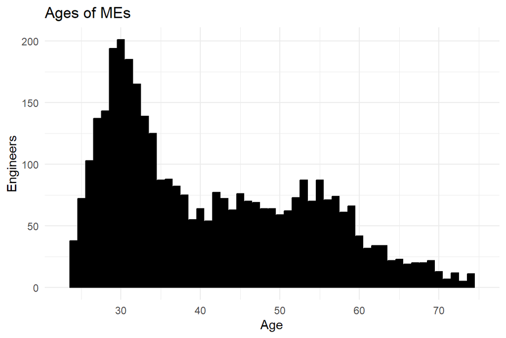

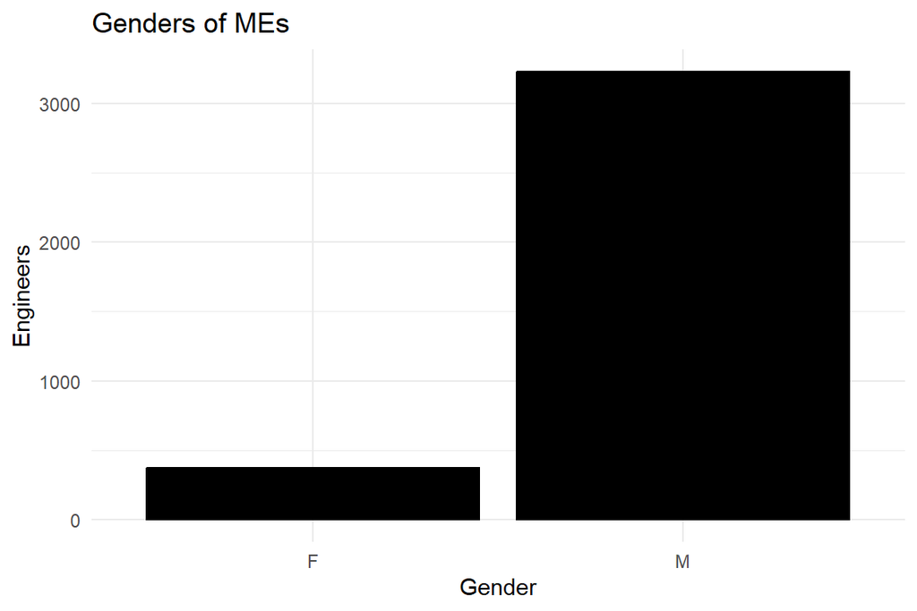

```
## [1] "Quantile Salaries:  105"     "Quantile Salaries:  96000"
## [3] "Quantile Salaries:  1027653"
```

```
## [1] "Quantile Ages:  23" "Quantile Ages:  38" "Quantile Ages:  75"
```

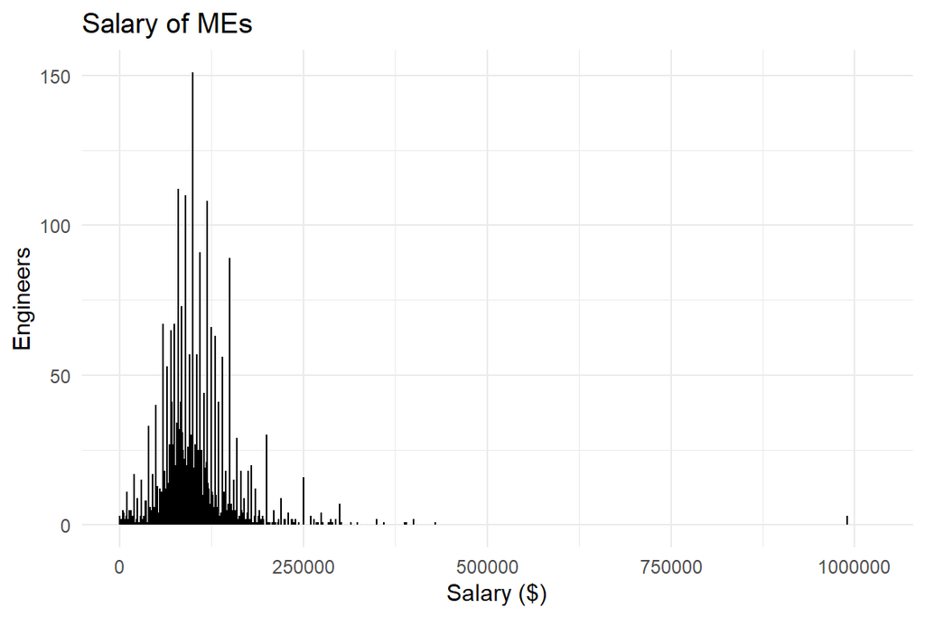

## Question 3: Multivariate histograms

Create a histogram of `salary`, faceted by `gender`. Add `bins = 50` and `color = "lightgrey"`.

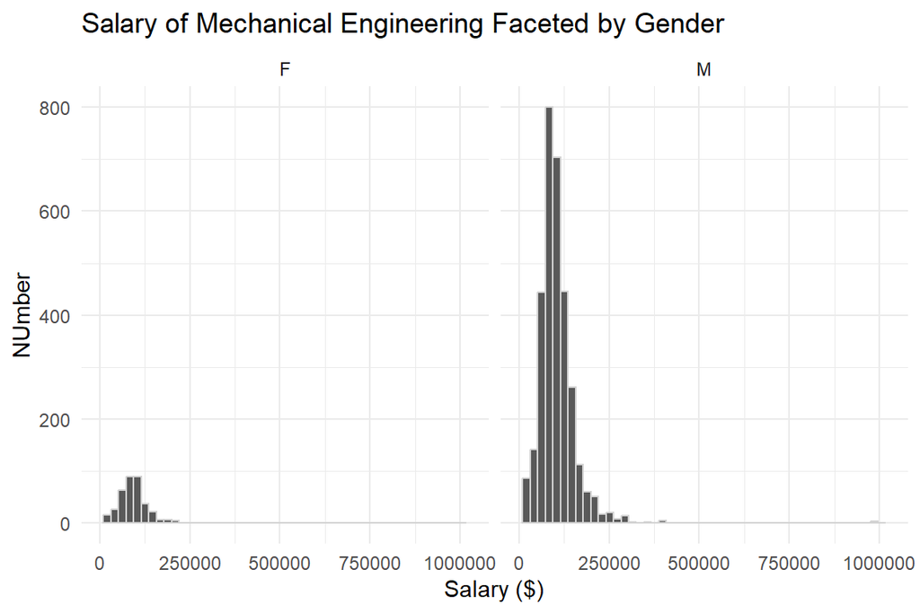

Create a histogram of `age`, faceted by `gender`. Add `bins = 50` and `color = "lightgrey"`.

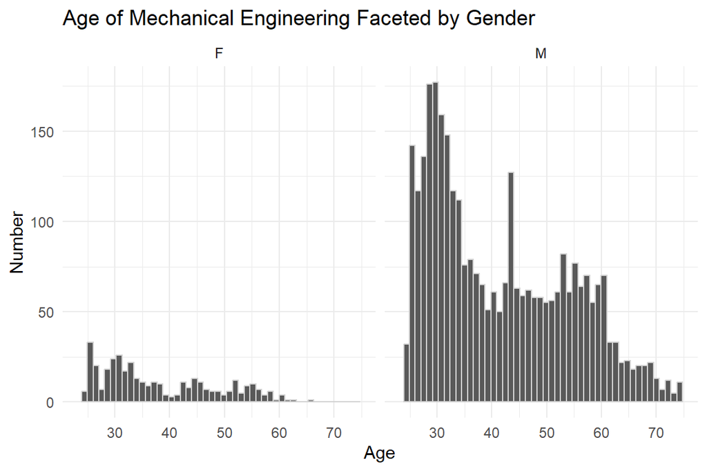

## Question 4: Multivariate boxplots

Create a boxplot of `salary`, faceted by `gender`. Use `oulier.shope = 1` to better visualize the outliers.

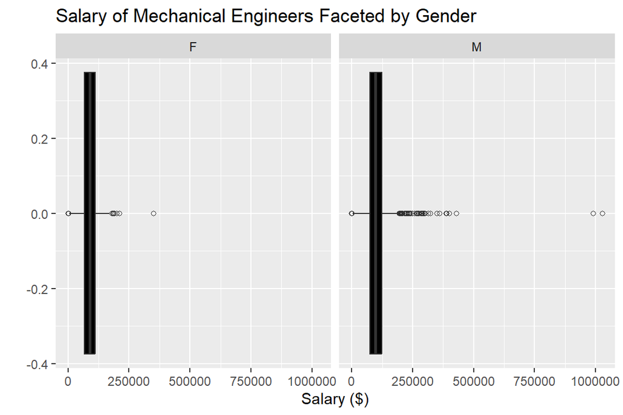

Create a boxplot of `age`, faceted by `gender`.

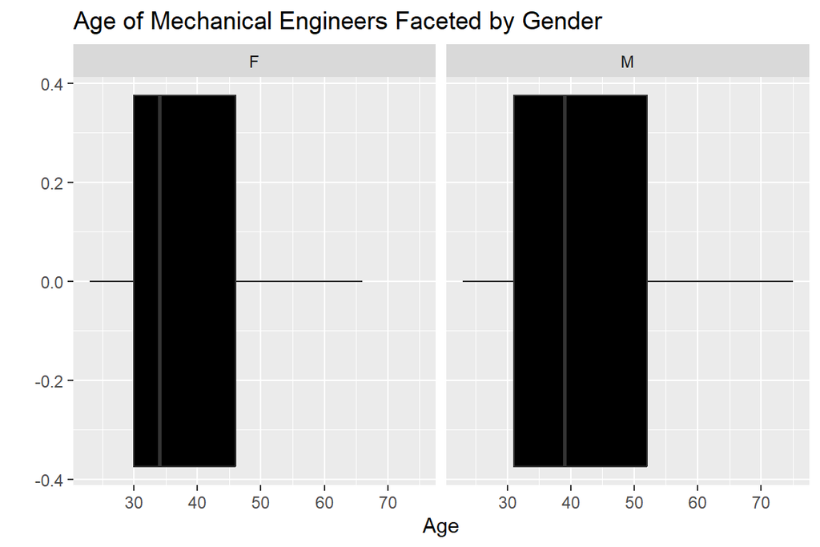

## Question 5: Scatterplot and correlation

Create a scatterplot of `age` (x-axis) and `salary`, differentiating by `gender`.

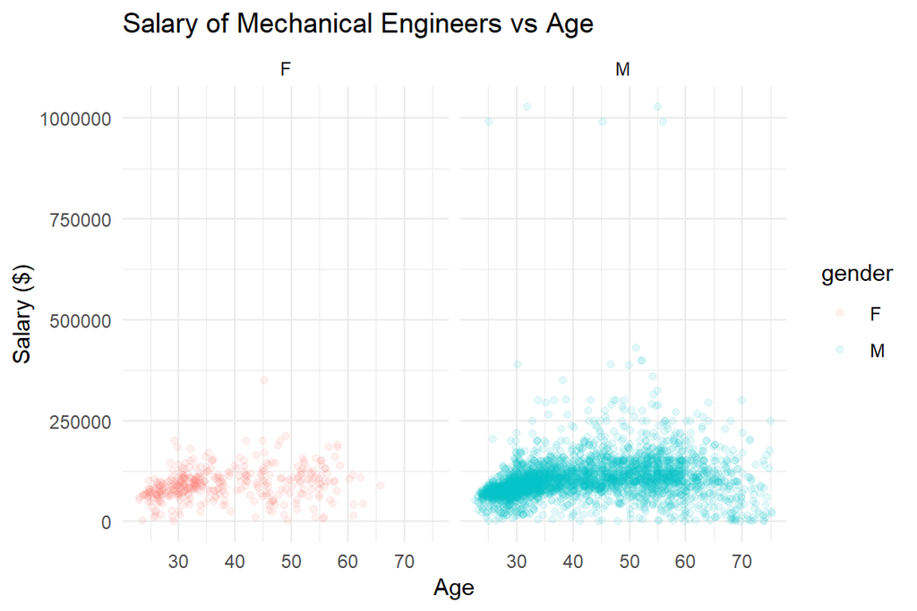

*Bonus point*: Is there a correlation between an engineer’s salary and age? What is the estimated Pearson correlation coefficient *r*? Run a formal test.

## Question 6: Cumulative distribution function

Plot the cumulative distribution function of `salary` by `gender`. Adjust the x-axis with `scale_x_log10(limits = c(5e4, 5e5))` to zoom in a bit. What do you notice about the salaries for men and women? Hint: Remember there are greater differences the farther up you go on a log scale axis.

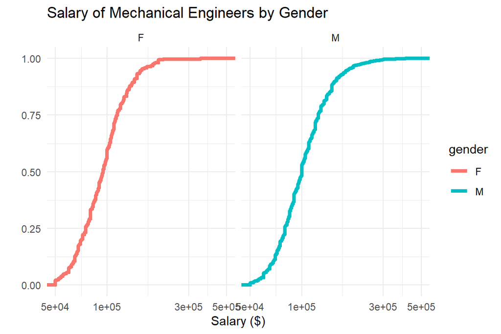

## Question 7: Quantiles

Calculate the quantiles of `salary` by `gender`. You can either subset the data with `dplyr::filter()` and dataframe assignment, or you can group by, summarize by quantile, and ungroup.

*Bonus point*: Assign the output to a dataframe, and use inline code to call individual values when answering the following questions. Do not let R use scientific notation in the text output; check the knitted document.

```
## # A tibble: 2 × 6
##   gender   Min Lower Median  Upper     Max
##   <fct>  <dbl> <dbl>  <dbl>  <dbl>   <dbl>
## 1 F        140 68000  90000 110513  350000
## 2 M        105 75000  97000 123000 1027653
```

What is the difference in salary between men and women at the median?

- Median salary for women is 90k
- Median salary for men is 97k
- The difference at the median is 7k

At the top percentile (maximum)?

Do you think there is a salary difference by gender across the pay scale? What other information would you need to test your hypothesis?

I do think there is a salary difference across the pay scale, I would test this buy further breaking up my quantiles in high definition.

## Question 8: Hypothetical analysis

Think about what other variables you would like to include in an hypothetical analysis. From your perspective, what are the most important individual, family, and workforce factors related to salary—beyond gender and age?

Prior experience, hight/weight

## Question 9: Recreate plot

# Appendix

```r
# set global options for figures, code, warnings, and messages
knitr::opts_chunk$set(fig.width=6, fig.height=4, fig.path="../figs/",
                      echo=FALSE, warning=FALSE, message=FALSE)
# load packages for current session
library("tidyverse")
library("readr")
library("dplyr")
library("magrittr")
library("ggplot2")
library("stringr")

# import and tidy salary data
salary_data_raw <- tibble(readr::read_csv(file ="../data/ME_salaries.csv"))
salary_data_clean <- salary_data_raw%>%
dplyr::rename(salary = SALARY, age = AGE, gender = GENDER)%>%
dplyr::filter(salary != 0)

salary_data_clean$gender <- as.factor(salary_data_clean$gender)

# number of observations with salary as 0
zeros <- sum(salary_data_raw$SALARY == 0)
print(zeros)
# number of factor levels
gender_levs <- levels(salary_data_clean$gender)
print(gender_levs)
# univariate eda
head(salary_data_clean)

#age stuff
age_quantiles <- quantile(salary_data_clean$age,
                         probs = seq(0, 1, 0.5))
paste("Quantile Ages: ", age_quantiles)


age_plot <- ggplot(salary_data_clean, aes(x = age)) +
geom_bar(aes(x = age),
bins = 100,
color = "black",
fill = 'black') +
xlim(min(salary_data_clean$age),
max(salary_data_clean$age)) +
labs(x = "Age",
y = "Engineers",
title = "Ages of MEs") +
theme_minimal()

print(age_plot)

#gender stuff
gen_plot <- ggplot(salary_data_clean)  +
    geom_bar(aes(x = gender),
color = "black",
fill = 'black') +
labs(x = "Gender",
y = "Engineers",
title = "Genders of MEs") +
theme_minimal()

print(gen_plot)

#salary stuffs

salary_quantiles <- quantile(salary_data_clean$salary,
                         probs = seq(0, 1, 0.5))
paste("Quantile Salaries: ", salary_quantiles)

age_quantiles <- quantile(salary_data_clean$age,
                         probs = seq(0, 1, 0.5))
paste("Quantile Ages: ", age_quantiles)


sal_plot <- ggplot(salary_data_clean, aes(x = salary)) +
geom_bar(aes(x = salary),
bins = 100,
color = "black",
fill = 'green') +
xlim(min(salary_data_clean$salary),
max(salary_data_clean$salary)) +
labs(x = "Salary ($)",
y = "Engineers",
title = "Salary of MEs") +
theme_minimal()

print(sal_plot)



# histogram of salaries split by gender
gender_hist <- ggplot(salary_data_clean,
                      aes(x = salary)) +
  geom_histogram(bins = 50,
                 color = "lightgrey") +
  xlim(min(salary_data_clean$salary),
       max(salary_data_clean$salary) )+
  facet_wrap(salary_data_clean$gender, ncol = 2) +
  labs(x = "Salary ($)",
       y = "NUmber",
       title = "Salary of Mechanical Engineering Faceted by Gender")+
  theme_minimal()
  print(gender_hist)
# histogram of ages split by gender
gender_hist_age <- ggplot(salary_data_clean,
                      aes(x = age)) +
  geom_histogram(bins = 50,
                 color = "lightgrey") +
  xlim(min(salary_data_clean$age),
       max(salary_data_clean$age) )+
  facet_wrap(salary_data_clean$gender, ncol = 2) +
  labs(x = "Age",
       y = "Number",
       title = "Age of Mechanical Engineering Faceted by Gender")+
  theme_minimal()
  print(gender_hist_age)
# boxplots of salary data by gender
salary_box <- ggplot(salary_data_clean,
                     aes(x = salary)) +
  geom_boxplot(outlier.shape = 1,
               fill = "black") +
  xlim(min(salary_data_clean$salary),
       max(salary_data_clean$salary)) +
  labs(x = "Salary ($)",
       y = "",
       title = "Salary of Mechanical Engineers Faceted by Gender") +
  facet_wrap(salary_data_clean$gender, ncol = 2) +
  theme_gray()

  print(salary_box)
# boxplots of age data by gender

age_box <- ggplot(salary_data_clean,
                     aes(x = age)) +
  geom_boxplot(outlier.shape = 1,
               fill = "black") +
  xlim(min(salary_data_clean$age),
       max(salary_data_clean$age)) +
  labs(x = "Age",
       y = "",
       title = "Age of Mechanical Engineers Faceted by Gender") +
  facet_wrap(salary_data_clean$gender, ncol = 2) +
  theme_gray()

  print(age_box)

# scatterplot of salary across age by gender
age_scatter <- ggplot(salary_data_clean,
    aes(x = age, y = salary, color = gender)) +
    geom_jitter(alpha = 0.1) +
    labs(x ="Age",
         y = "Salary ($)",
         title = "Salary of Mechanical Engineers vs Age") +
    facet_wrap(salary_data_clean$gender, ncol = 2) +
  theme_minimal()

print(age_scatter)


# correlation test

# plot cdf of salary by gender

salary_ecdf <- ggplot(salary_data_clean,
                           aes(x = salary, color = gender )) +
  stat_ecdf(geom = "step", size = 1.5) +
  labs(x = "Salary ($)",
       y = "",
       title = "Salary of Mechanical Engineers by Gender") +
  scale_x_log10(limits = c(5e4, 5e5))+
  facet_wrap(salary_data_clean$gender, ncol = 2) +
 theme_minimal()

print(salary_ecdf)


# calculate quantiles of salary by gender


salary_quantiles <- salary_data_clean %>%
  group_by(gender) %>%
  summarize(Min = quantile(salary, 0),
            Lower = quantile(salary, 0.25),
            Median = quantile(salary, 0.5),
            Upper = quantile(salary, 0.75),
            Max = quantile(salary, 1)) %>%
  ungroup()

print(salary_quantiles)

# call mpg pdf - you need to recreate it


#knitr::include_graphics("./mpg-ch7-plot.pdf")
```